# home work

```r
library(tidyverse)
library(readr)
```

Question 1

Load in the dataset and call it drinks_content, eyeball it by printing it out (first 5 rows, last 5 rows, and then all of the data) and find out the dimensions (number of rows/columns) and variable names.

```r
drinks_content <- read_csv("data/starbucks_drinkMenu_expanded.csv")
```

```r
head(drinks_content, 5)
```

| Beverage_category | Beverage | Beverage_prep | Calories | Total Fat (g) | Trans Fat (g) | Saturated Fat (g) | Sodium (mg) | Total Carbohydrates (g) | Cholesterol (mg) | Dietary Fibre (g) | Sugars (g) | Protein (g) | Vitamin A (% DV) | Vitamin C (% DV) | Calcium (% DV) | Iron (% DV) | Caffeine (mg) |
| --- | --- | --- | --- | --- | --- | --- | --- | --- | --- | --- | --- | --- | --- | --- | --- | --- | --- |
| Coffee | Brewed Coffee | Short | 3 | 0.1 | 0.0 | 0 | 0 | 5 | 0 | 0 | 0 | 0.3 | 0% | 0% | 0% | 0% | 175 |
| Coffee | Brewed Coffee | Tall | 4 | 0.1 | 0.0 | 0 | 0 | 10 | 0 | 0 | 0 | 0.5 | 0% | 0% | 0% | 0% | 260 |
| Coffee | Brewed Coffee | Grande | 5 | 0.1 | 0.0 | 0 | 0 | 10 | 0 | 0 | 0 | 1.0 | 0% | 0% | 0% | 0% | 330 |
| Coffee | Brewed Coffee | Venti | 5 | 0.1 | 0.0 | 0 | 0 | 10 | 0 | 0 | 0 | 1.0 | 0% | 0% | 2% | 0% | 410 |
| Classic Espresso Drinks | Caffè Latte | Short Nonfat Milk | 70 | 0.1 | 0.1 | 0 | 5 | 75 | 10 | 0 | 9 | 6.0 | 10% | 0% | 20% | 0% | 75 |

```r
tail(drinks_content, 5)
```

| Beverage_category | Beverage | Beverage_prep | Calories | Total Fat (g) | Trans Fat (g) | Saturated Fat (g) | Sodium (mg) | Total Carbohydrates (g) | Cholesterol (mg) | Dietary Fibre (g) | Sugars (g) | Protein (g) | Vitamin A (% DV) | Vitamin C (% DV) | Calcium (% DV) | Iron (% DV) | Caffeine (mg) |
| --- | --- | --- | --- | --- | --- | --- | --- | --- | --- | --- | --- | --- | --- | --- | --- | --- | --- |
| Frappuccino® Blended Crème | Strawberries & Crème (Without Whipped Cream) | Soymilk | 320 | 3 2 | 0.4 | 0.0 | 0 | 250 | 67 | 1 | 64 | 5 | 6% | 8% | 20% | 10% | 0 |
| Frappuccino® Blended Crème | Vanilla Bean (Without Whipped Cream) | Tall Nonfat Milk | 170 | 0.1 | 0.1 | 0.0 | 0 | 160 | 39 | 0 | 38 | 4 | 6% | 0% | 10% | 0% | 0 |
| Frappuccino® Blended Crème | Vanilla Bean (Without Whipped Cream) | Whole Milk | 200 | 3.5 | 2.0 | 0.1 | 10 | 160 | 39 | 0 | 38 | 3 | 6% | 0% | 10% | 0% | 0 |
| Frappuccino® Blended Crème | Vanilla Bean (Without Whipped Cream) | Soymilk | 180 | 1.5 | 0.2 | 0.0 | 0 | 160 | 37 | 1 | 35 | 3 | 4% | 0% | 10% | 6% | 0 |
| Frappuccino® Blended Crème | Vanilla Bean (Without Whipped Cream) | Grande Nonfat Milk | 240 | 0.1 | 0.1 | 0.0 | 5 | 230 | 56 | 0 | 55 | 5 | 8% | 0% | 15% | 0% | 0 |

```r
drinks_content
```

| Beverage_category | Beverage | Beverage_prep | Calories | Total Fat (g) | Trans Fat (g) | Saturated Fat (g) | Sodium (mg) | Total Carbohydrates (g) | Cholesterol (mg) | Dietary Fibre (g) | Sugars (g) | Protein (g) | Vitamin A (% DV) | Vitamin C (% DV) | Calcium (% DV) | Iron (% DV) | Caffeine (mg) |
| --- | --- | --- | --- | --- | --- | --- | --- | --- | --- | --- | --- | --- | --- | --- | --- | --- | --- |
| Coffee | Brewed Coffee | Short | 3 | 0.1 | 0.0 | 0.0 | 0 | 5 | 0 | 0 | 0 | 0.3 | 0% | 0% | 0% | 0% | 175 |
| Coffee | Brewed Coffee | Tall | 4 | 0.1 | 0.0 | 0.0 | 0 | 10 | 0 | 0 | 0 | 0.5 | 0% | 0% | 0% | 0% | 260 |
| Coffee | Brewed Coffee | Grande | 5 | 0.1 | 0.0 | 0.0 | 0 | 10 | 0 | 0 | 0 | 1.0 | 0% | 0% | 0% | 0% | 330 |
| Coffee | Brewed Coffee | Venti | 5 | 0.1 | 0.0 | 0.0 | 0 | 10 | 0 | 0 | 0 | 1.0 | 0% | 0% | 2% | 0% | 410 |
| Classic Espresso Drinks | Caffè Latte | Short Nonfat Milk | 70 | 0.1 | 0.1 | 0.0 | 5 | 75 | 10 | 0 | 9 | 6.0 | 10% | 0% | 20% | 0% | 75 |
| Classic Espresso Drinks | Caffè Latte | 2% Milk | 100 | 3.5 | 2.0 | 0.1 | 15 | 85 | 10 | 0 | 9 | 6.0 | 10% | 0% | 20% | 0% | 75 |
| Classic Espresso Drinks | Caffè Latte | Soymilk | 70 | 2.5 | 0.4 | 0.0 | 0 | 65 | 6 | 1 | 4 | 5.0 | 6% | 0% | 20% | 8% | 75 |
| Classic Espresso Drinks | Caffè Latte | Tall Nonfat Milk | 100 | 0.2 | 0.2 | 0.0 | 5 | 120 | 15 | 0 | 14 | 10.0 | 15% | 0% | 30% | 0% | 75 |
| Classic Espresso Drinks | Caffè Latte | 2% Milk | 150 | 6 | 3.0 | 0.2 | 25 | 135 | 15 | 0 | 14 | 10.0 | 15% | 0% | 30% | 0% | 75 |
| Classic Espresso Drinks | Caffè Latte | Soymilk | 110 | 4.5 | 0.5 | 0.0 | 0 | 105 | 10 | 1 | 6 | 8.0 | 10% | 0% | 30% | 15% | 75 |

[output cut: 232 more lines]

```r
NA
NA
```

```r
dim(drinks_content)
```

```
[1] 242  18
```

```r
names(drinks_content)
```

```
 [1] "Beverage_category"       "Beverage"
 [3] "Beverage_prep"           "Calories"
 [5] "Total Fat (g)"           "Trans Fat (g)"
 [7] "Saturated Fat (g)"       "Sodium (mg)"
 [9] "Total Carbohydrates (g)" "Cholesterol (mg)"
[11] "Dietary Fibre (g)"       "Sugars (g)"
[13] "Protein (g)"             "Vitamin A (% DV)"
[15] "Vitamin C (% DV)"        "Calcium (% DV)"
[17] "Iron (% DV)"             "Caffeine (mg)"
```

Question 2

Calculate some quick summary statistics to check the mean and the variance of the Calories variable. Also create a histogram of the Calories variable. Write a quick summary of your initial impressions of the data.

```r
summary(drinks_content$Calories)
```

```
   Min. 1st Qu.  Median    Mean 3rd Qu.    Max.
    0.0   120.0   185.0   193.9   260.0   510.0
```

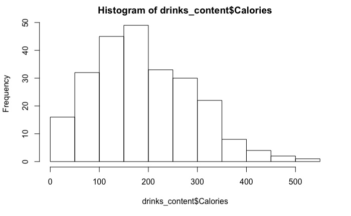

```r
hist(drinks_content$Calories)
```

Question 3

Check if you have any outliers in the Calories variable by creating a boxplot. Then get the actual values of any outliers you have. Finally, decide what you want to do here. Do you want to remove the outliers? Do you want to keep them? Justify your decision either way. As you work through your outlier identification and removal process, write a summary of what you find (i.e. do you find any outliers), what you decide to do (why you are removing them or not, what criteria you might use), and how you removed them if you did (e.g. did you remove all or not).

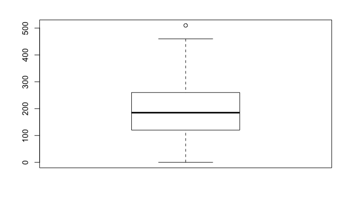

```r
boxplot(drinks_content$Calories)
```

```r
NA
NA
```

```r
outliers <- boxplot(drinks_content$Calories, plot = FALSE)$out

print(outliers)
```

```
[1] 510
```

```r
drinks_content[which(drinks_content$Calories %in% outliers), ]
```

| Beverage_category | Beverage | Beverage_prep | Calories | Total Fat (g) | Trans Fat (g) | Saturated Fat (g) | Sodium (mg) | Total Carbohydrates (g) | Cholesterol (mg) | Dietary Fibre (g) | Sugars (g) | Protein (g) | Vitamin A (% DV) | Vitamin C (% DV) | Calcium (% DV) | Iron (% DV) | Caffeine (mg) |
| --- | --- | --- | --- | --- | --- | --- | --- | --- | --- | --- | --- | --- | --- | --- | --- | --- | --- |
| Signature Espresso Drinks | White Chocolate Mocha (Without Whipped Cream) | 2% Milk | 510 | 15 | 9 | 0.2 | 35 | 330 | 77 | 0 | 74 | 19 | 20% | 4% | 60% | 2% | 150 |

```r
NA
```

```r
drinks_content_outlier <-
drinks_content[-which(drinks_content$Calories %in% outliers),]
```

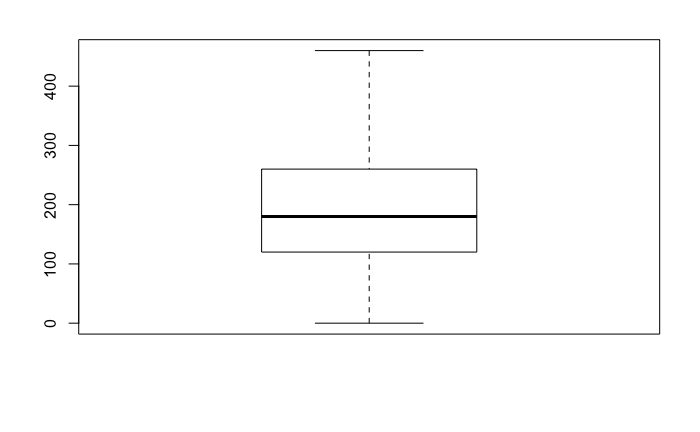

```r
boxplot(drinks_content_outlier$Calories)
```

Question 4

Select the variables beverage_category, beverage, beverage prep and calories from your data. Since we are interested in the calorie content, check if there are any NA values in the data, and drop them if there are.

```r
drink_calories <- select(drinks_content, Beverage_category, Beverage, Beverage_prep, Calories)

# check for NA's

is.na(drink_calories$Calories)
```

[output not shown]

Question 5

Filter the data so we only take “classic espresso drinks

```r
classic_espresso_drinks <-
                        filter(drinks_content, Beverage_category == "Classic Espresso Drinks" )
```

Question 6

Create a new tibble called drink_calories which contains a variable called calorie_diff. calorie_diff should store the difference between 135 calories (135 calories = 10 cubes of sugar!) and the calories in each drink. (hint: you’ll want to subtract the calories from 135 to see which drink have more or less than 10 cups of sugar).

```r
drink_calories <- mutate(classic_espresso_drinks, calorie_diff = 135 - Calories)
```

Question 7

Create a new tibble called drinks_grouped where you group your data by the type of beverage prep. Then summarise the mean calories in each drink (by group) in a variable called mean_cal, and save it to drinks_summary. Finally arrange this summary data in descending order of mean calories.

```r
# group the data
drinks_grouped <- group_by(drink_calories, Beverage_prep)

# summarise the data
drinks_summary <- summarise(drinks_grouped, mean_cal = mean(Calories))

# arrange in descending order
arrange(drinks_summary,desc(mean_cal))
```

[output not shown]

Hopefully you can see by now how much hassle it can be to constantly keep creating tibbles to store all your data. Finish up by using the %>% operator to put all the answers you’ve got from questions 4-7 into one pipe. You don’t need to include the check for NA values in this, as you’d typically check that before you start doing any analysis.

```r
drink_pipe <- drinks_content %>%

              select(Beverage_category, Beverage, Beverage_prep, Calories) %>%
              filter(Beverage_category == "Classic Espresso Drinks" ) %>%
              mutate(calorie_diff = 135 - Calories) %>%
              group_by(Beverage_prep) %>%
              summarise(mean_cal = mean(Calories)) %>%
              arrange(desc(mean_cal))
```

Use the drink_calories data to find the two drinks (Beverage) with least and most Calories. (Hint: use the min_rank() function)

```r
least_calories <- drink_calories %>%
                  arrange(Calories) %>%
                  mutate(ranking = min_rank(Calories)) %>%
                  filter(ranking <=2)

least_calories
```

| Beverage_category | Beverage | Beverage_prep | Calories | Total Fat (g) | Trans Fat (g) | Saturated Fat (g) | Sodium (mg) | Total Carbohydrates (g) | Cholesterol (mg) | Dietary Fibre (g) | Sugars (g) | Protein (g) | Vitamin A (% DV) | Vitamin C (% DV) | Calcium (% DV) | Iron (% DV) | Caffeine (mg) | calorie_diff | ranking |
| --- | --- | --- | --- | --- | --- | --- | --- | --- | --- | --- | --- | --- | --- | --- | --- | --- | --- | --- | --- |
| Classic Espresso Drinks | Caffè Americano | Short | 5 | 0 | 0 | 0 | 0 | 5 | 1 | 0 | 0 | 0.4 | 0% | 0% | 0% | 0% | 75 | 130 | 1 |
| Classic Espresso Drinks | Espresso | Solo | 5 | 0 | 0 | 0 | 0 | 0 | 1 | 0 | 0 | 0.4 | 0% | 0% | 0% | 0% | 75 | 130 | 1 |

```r
most_calories <- drink_calories %>%
                  arrange(Calories) %>%
                  mutate(ranking = min_rank(desc(Calories))) %>%
                  filter(ranking <=2)

most_calories
```

| Beverage_category | Beverage | Beverage_prep | Calories | Total Fat (g) | Trans Fat (g) | Saturated Fat (g) | Sodium (mg) | Total Carbohydrates (g) | Cholesterol (mg) | Dietary Fibre (g) | Sugars (g) | Protein (g) | Vitamin A (% DV) | Vitamin C (% DV) | Calcium (% DV) | Iron (% DV) | Caffeine (mg) | calorie_diff | ranking |
| --- | --- | --- | --- | --- | --- | --- | --- | --- | --- | --- | --- | --- | --- | --- | --- | --- | --- | --- | --- |
| Classic Espresso Drinks | Vanilla Latte (Or Other Flavoured Latte) | 2% Milk | 320 | 9 | 4.5 | 0.3 | 35 | 200 | 46 | 0 | 44 | 15 | 25% | 2% | 45% | 0% | 150 | -185 | 2 |
| Classic Espresso Drinks | Caffè Mocha (Without Whipped Cream) | 2% Milk | 340 | 11 | 6.0 | 0.2 | 30 | 180 | 53 | 2 | 43 | 17 | 20% | 2% | 45% | 30% | 180 | -205 | 1 |

```r
NA
NA
```